# Solución tarea 2

Andrea Romero Magaña

13/10/2020

### **Regresión escalonada**

La regresión escalonada (“stepwise regression”) es un procedimiento que pretende construir un modelo de regresión a partir de un conjunto de variables predictoras candidatas, ingresando y eliminando predictores de manera escalonada en el modelo hasta que no haya una razón “estadísticamente válida” para ingresar o quitar más variables. El objetivo de esta tarea es evaluar la robustez estadística de dicho método.

#### **Ejercicio 1**

Primero, se corrió `source()` para cargar la función `replicar_reg_scal()` en el ambiente de trabajo. Esta función simula datos con múltiples variables predictoras con un número de variables definidas (`nvars`), los cuales pueden ser analizados con una regresión escalonada.

```r
# se corre en el repositorio clonado local
source("C:/Users/andrearomero/Documents/Andrea - Img, doc, etc/2020/CICLO II-2020/Herramientas prácticas para investigación reproducible/6_Reportes dinámicos/curso_reproducible/scripts/replicar_reg_scal.R")
```

Posteriormente, se calculó la proporción de réplicas que produjeron al menos una variable con un efecto significativo (i.e. proporción de falsos positivos) para números de variables **10, 20, 50 y 100** (se varía el argumento `nvars`) con un alfa de **0.05**:

Proporción de falsos positivos para `nvars = 10`

```r
# Se corre la función con número de variables (nvars) igual a 10. El argumento itr es el número de iteraciones o réplicas, n es el número de observaciones en cada variable y el alpha es el umbral para definir significancia estadística en los valores de p.
falsos_positivos1 <- replicar_reg_scal(itr = 100, n = 30, nvars = 10, alfa = 0.05)

falsos_positivos1
```

```
## [1] 0.24
```

Proporción de falsos positivos para `nvars = 20`

```r
# Se corre la función con número de variables (nvars) igual a 20 y alfa de 0.05.
falsos_positivos2 <- replicar_reg_scal(itr = 100, n = 30, nvars = 20, alfa = 0.05)

falsos_positivos2
```

```
## [1] 0.25
```

Proporción de falsos positivos para `nvars = 50`

```r
# Se corre la función con número de variables (nvars) igual a 50 y alfa de 0.05.
falsos_positivos3 <- replicar_reg_scal(itr = 100, n = 30, nvars = 50, alfa = 0.05)

falsos_positivos3
```

```
## [1] 0.38
```

Proporción de falsos positivos para `nvars = 100`

```r
# Se corre la función con número de variables (nvars) igual a 100 y alfa de 0.05.
falsos_positivos4 <- replicar_reg_scal(itr = 100, n = 30, nvars = 100, alfa = 0.05)

falsos_positivos4
```

```
## [1] 0.43
```

Se graficó el número de variables vs. la proporción de falsos positivos.

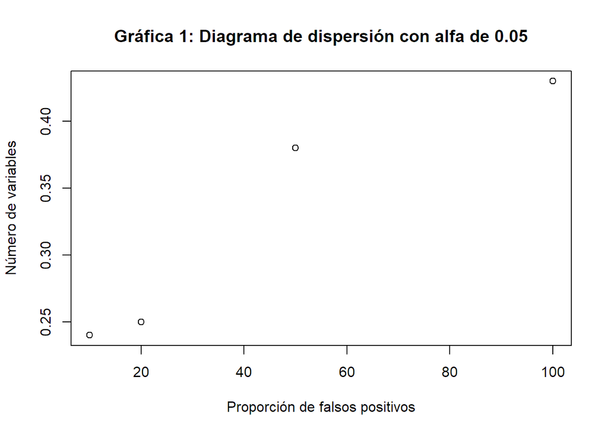

```r
# Se definen las variables x & y (x = proporcion_de_falsos_positivos; y = numero_de_variables)

proporcion_de_falsos_positivos <- c(falsos_positivos1, falsos_positivos2, falsos_positivos3, falsos_positivos4)

numero_de_variables <- c(10, 20, 50, 100)

# Se corre la función plot para hacer un gráfico de dispersión

plot(numero_de_variables, proporcion_de_falsos_positivos, ylab = "Número de variables", xlab= "Proporción de falsos positivos", main="Gráfica 1: Diagrama de dispersión con alfa de 0.05")
```

#### **Ejercicio 2**

Se repitió los ejercicios anteriores, pero esta vez variando el argumento `alfa` a **0.02**:

Proporción de falsos positivos para `nvars = 10`

```r
# Se corre la función con número de variables (nvars) igual a 10 y alfa de 0.02.
falsos_positivos5 <- replicar_reg_scal(itr = 100, n = 30, nvars = 10, alfa = 0.02)

falsos_positivos5
```

```
## [1] 0.1
```

Proporción de falsos positivos para `nvars = 20`

```r
# Se corre la función con número de variables (nvars) igual a 20 y alfa de 0.02.
falsos_positivos6 <- replicar_reg_scal(itr = 100, n = 30, nvars = 20, alfa = 0.02)

falsos_positivos6
```

```
## [1] 0.12
```

Proporción de falsos positivos para `nvars = 50`

```r
# Se corre la función con número de variables (nvars) igual a 50 y alfa de 0.02.
falsos_positivos7 <- replicar_reg_scal(itr = 100, n = 30, nvars = 50, alfa = 0.02)

falsos_positivos7
```

```
## [1] 0.17
```

Proporción de falsos positivos para `nvars = 100`

```r
# Se corre la función con número de variables (nvars) igual a 100 y alfa de 0.02.
falsos_positivos8 <- replicar_reg_scal(itr = 100, n = 30, nvars = 100, alfa = 0.02)

falsos_positivos8
```

```
## [1] 0.19
```

Se graficó nuevamente el número de variables vs. la proporción de falsos positivos.

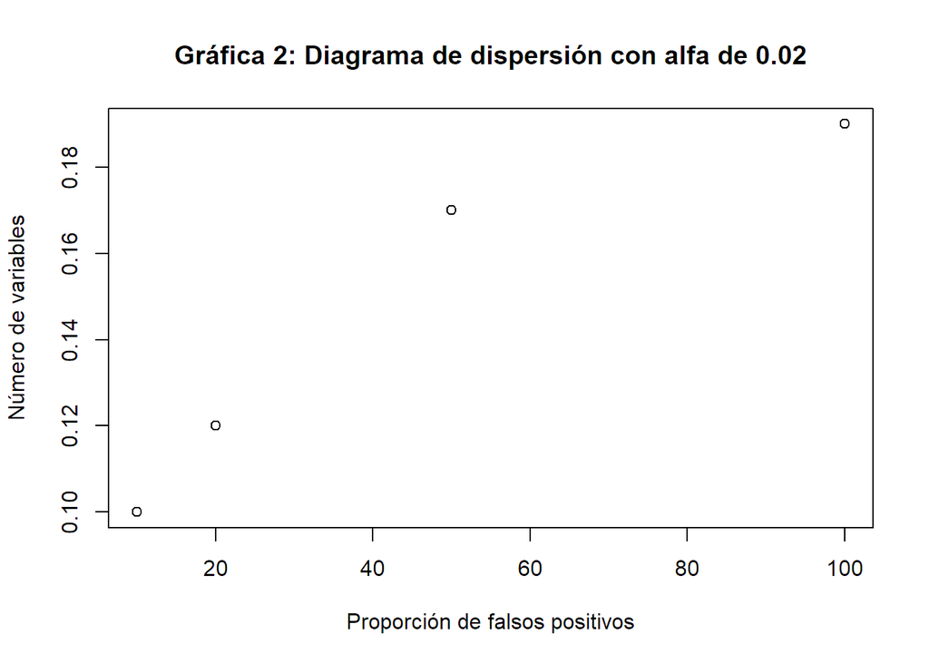

```r
# Se definen las variables x & y (x = proporcion_de_falsos_positivos; y = numero_de_variables)
proporcion_de_falsos_positivos <- c(falsos_positivos5, falsos_positivos6, falsos_positivos7, falsos_positivos8)

numero_de_variables <- c(10, 20, 50, 100)

# Se corre la función plot para hacer un gráfico de dispersión

plot(numero_de_variables, proporcion_de_falsos_positivos, ylab = "Número de variables", xlab= "Proporción de falsos positivos", main="Gráfica 2: Diagrama de dispersión con alfa de 0.02")
```

#### **Organismo favorito**

¡Me encantan estos animales! (Nota: no soy herpetóloga jaja)

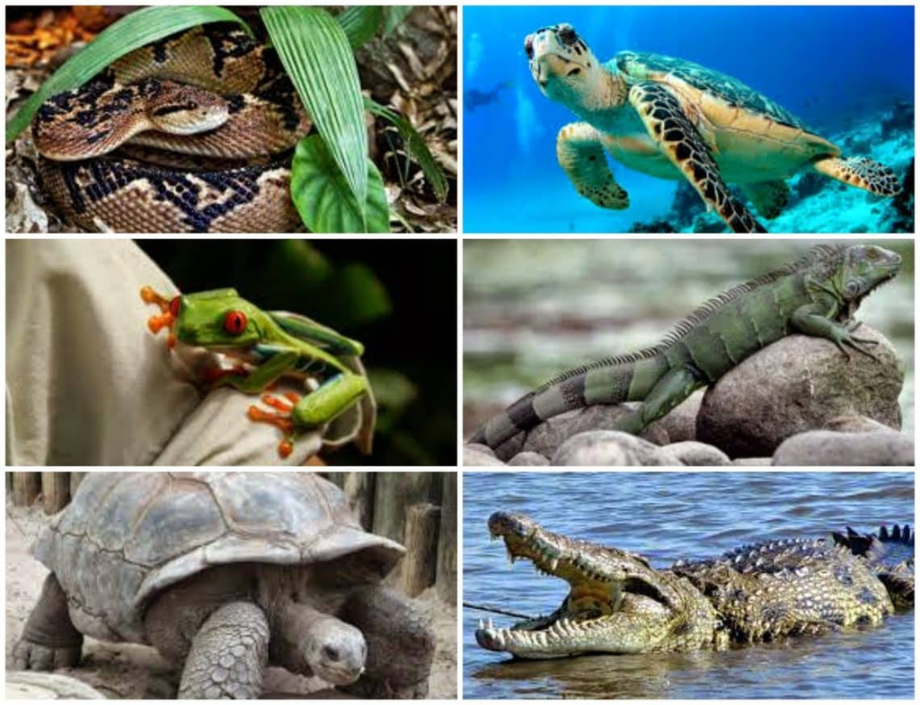

#### *Información de la sesión*